# Assignement2_DS

### 1.2.2 Data Exploration : Importing and exploring the Dataset

```r
rm(list=ls())


# Importing the dataset :
heart = read.csv("heart-disease.csv",header = F)

# The head of the dataset :
head(heart)
```

```
##   V1 V2 V3  V4  V5 V6 V7  V8 V9 V10 V11 V12 V13 V14
## 1 63  1  1 145 233  1  2 150  0 2.3   3 0.0 6.0   0
## 2 67  1  4 160 286  0  2 108  1 1.5   2 3.0 3.0   2
## 3 67  1  4 120 229  0  2 129  1 2.6   2 2.0 7.0   1
## 4 37  1  3 130 250  0  0 187  0 3.5   3 0.0 3.0   0
## 5 41  0  2 130 204  0  2 172  0 1.4   1 0.0 3.0   0
## 6 56  1  2 120 236  0  0 178  0 0.8   1 0.0 3.0   0
```

```r
tail(heart)
```

```
##     V1 V2 V3  V4  V5 V6 V7  V8 V9 V10 V11 V12 V13 V14
## 298 57  0  4 140 241  0  0 123  1 0.2   2 0.0 7.0   1
## 299 45  1  1 110 264  0  0 132  0 1.2   2 0.0 7.0   1
## 300 68  1  4 144 193  1  0 141  0 3.4   2 2.0 7.0   2
## 301 57  1  4 130 131  0  0 115  1 1.2   2 1.0 7.0   3
## 302 57  0  2 130 236  0  2 174  0 0.0   2 1.0 3.0   1
## 303 38  1  3 138 175  0  0 173  0 0.0   1   ? 3.0   0
```

```r
# The number of rows of the dataset :
nrow(heart)
```

```
## [1] 303
```

```r
# Preparing column names :
names <- c("age",
           "sex",
           "cp",
           "trestbps",
           "chol",
           "fbs",
           "restecg",
           "thalach",
           "exang",
           "oldpeak",
           "slope",
           "ca",
           "thal",
           "target")

#Apply column names to the dataframe :
colnames(heart) <- names

#Glimpse data to verify that new column names are in place :
colnames(heart)
```

```
##  [1] "age"      "sex"      "cp"       "trestbps" "chol"     "fbs"
##  [7] "restecg"  "thalach"  "exang"    "oldpeak"  "slope"    "ca"
## [13] "thal"     "target"
```

```r
#Replacing values 1,2,3,4 by 1. So that, 0 is the absence of heart diseace and 1 is the presence of it.
for(i in 1:length(heart$target)){
  if(heart$target[i] >= 1){
    heart$target[i] = 1
  }
}

# Exploring now the structure and the values of our modified data :
str(heart)
```

```
## 'data.frame':    303 obs. of  14 variables:
##  $ age     : num  63 67 67 37 41 56 62 57 63 53 ...
##  $ sex     : num  1 1 1 1 0 1 0 0 1 1 ...
##  $ cp      : num  1 4 4 3 2 2 4 4 4 4 ...
##  $ trestbps: num  145 160 120 130 130 120 140 120 130 140 ...
##  $ chol    : num  233 286 229 250 204 236 268 354 254 203 ...
##  $ fbs     : num  1 0 0 0 0 0 0 0 0 1 ...
##  $ restecg : num  2 2 2 0 2 0 2 0 2 2 ...
##  $ thalach : num  150 108 129 187 172 178 160 163 147 155 ...
##  $ exang   : num  0 1 1 0 0 0 0 1 0 1 ...
##  $ oldpeak : num  2.3 1.5 2.6 3.5 1.4 0.8 3.6 0.6 1.4 3.1 ...
##  $ slope   : num  3 2 2 3 1 1 3 1 2 3 ...
##  $ ca      : Factor w/ 5 levels "?","0.0","1.0",..: 2 5 4 2 2 2 4 2 3 2 ...
##  $ thal    : Factor w/ 4 levels "?","3.0","6.0",..: 3 2 4 2 2 2 2 2 4 4 ...
##  $ target  : num  0 1 1 0 0 0 1 0 1 1 ...
```

```r
head(heart)
```

```
##   age sex cp trestbps chol fbs restecg thalach exang oldpeak slope  ca thal
## 1  63   1  1      145  233   1       2     150     0     2.3     3 0.0  6.0
## 2  67   1  4      160  286   0       2     108     1     1.5     2 3.0  3.0
## 3  67   1  4      120  229   0       2     129     1     2.6     2 2.0  7.0
## 4  37   1  3      130  250   0       0     187     0     3.5     3 0.0  3.0
## 5  41   0  2      130  204   0       2     172     0     1.4     1 0.0  3.0
## 6  56   1  2      120  236   0       0     178     0     0.8     1 0.0  3.0
##   target
## 1      0
## 2      1
## 3      1
## 4      0
## 5      0
## 6      0
```

```r
tail(heart)
```

```
##     age sex cp trestbps chol fbs restecg thalach exang oldpeak slope  ca thal
## 298  57   0  4      140  241   0       0     123     1     0.2     2 0.0  7.0
## 299  45   1  1      110  264   0       0     132     0     1.2     2 0.0  7.0
## 300  68   1  4      144  193   1       0     141     0     3.4     2 2.0  7.0
## 301  57   1  4      130  131   0       0     115     1     1.2     2 1.0  7.0
## 302  57   0  2      130  236   0       2     174     0     0.0     2 1.0  3.0
## 303  38   1  3      138  175   0       0     173     0     0.0     1   ?  3.0
##     target
## 298      1
## 299      1
## 300      1
## 301      1
## 302      1
## 303      0
```

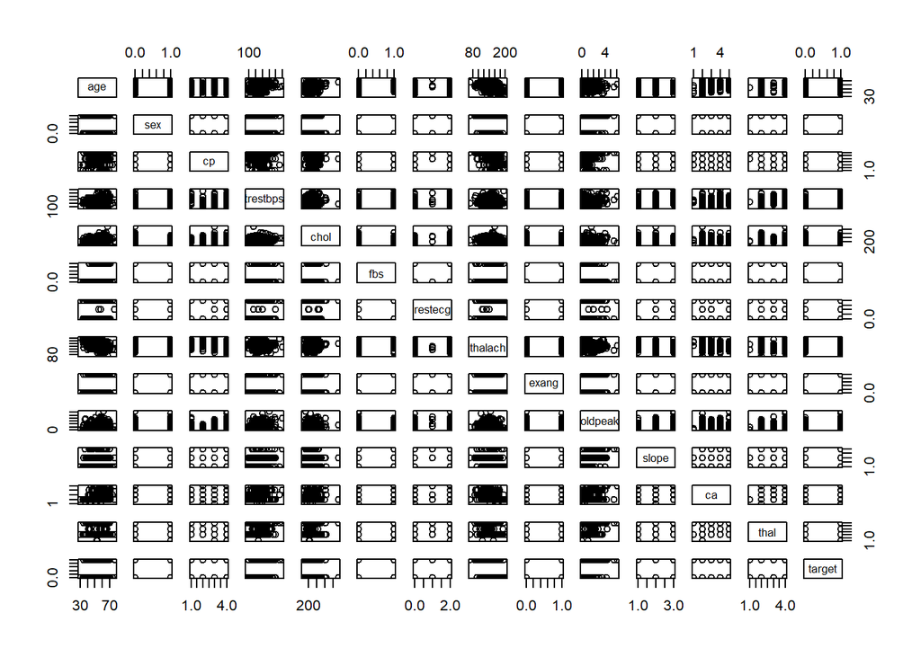

```r
plot(heart)
```

Let’s explore the dataset by using different plots and functions :

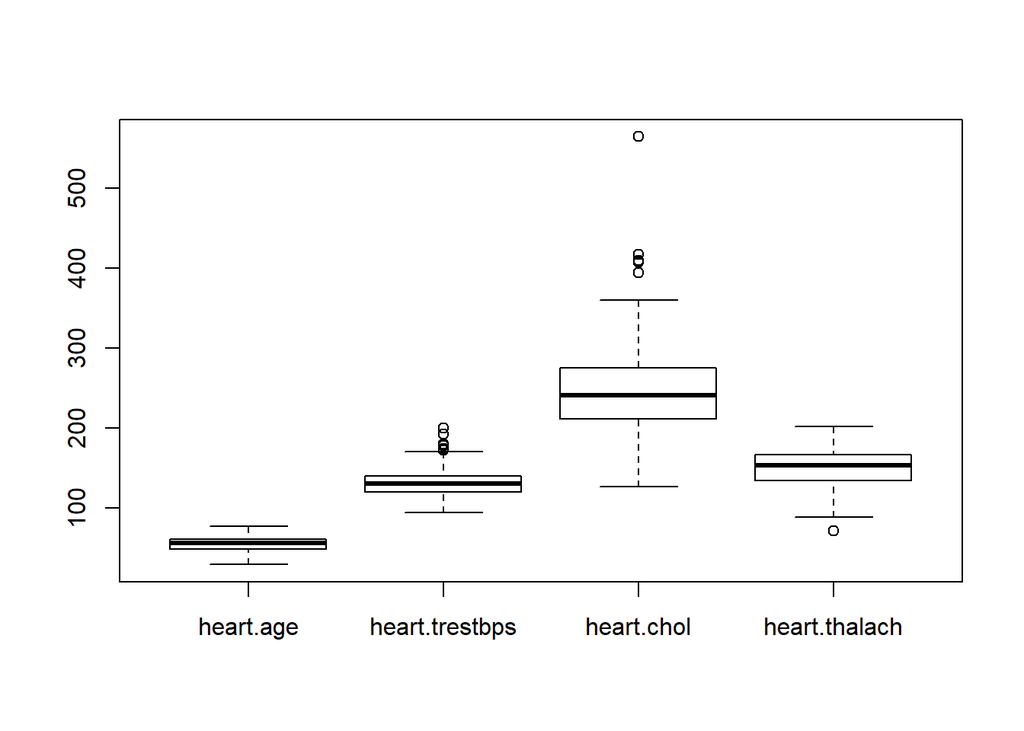

```r
# Boxplot of the variables that we suspect to be important :
databox=data.frame(heart$age, heart$trestbps,heart$chol,heart$thalach)
boxplot(databox)
```

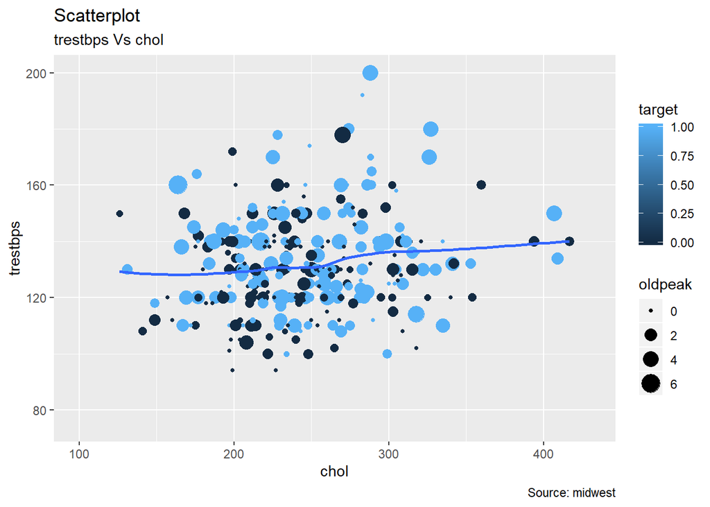

```r
# Scatterplot to compare the resting blood pressure vs serum cholestoral in mg/dl :
library(ggplot2)
gg <- ggplot(heart, aes(x=chol, y=trestbps)) +
  geom_point(aes(col=target, size=oldpeak)) +
  geom_smooth(method="loess", se=F) +
  xlim(c(100, 430)) +
  ylim(c(75, 200)) +
  labs(subtitle="trestbps Vs chol",
       y="trestbps",
       x="chol",
       title="Scatterplot",
       caption = "Source: midwest",
       bins = 30)
plot(gg)
```

### 1.2.3 Methodology :

#### 1.2.3.1 Step 1 : Splitting the Dataset into training and testing set.

First, we will split our data into a training set and a testing set.

```r
set.seed(13)
n <- length(heart$target)
index <- sample(1:n,floor(n*0.7))

# Splitting the data :
train <- heart[index,]
test <- heart[-index,]
```

#### 1.2.3.2 Step 2 : Building our linear model

We will now build our linear model using interactions to have the best model possible.

```r
# Linear model :
model.linear <- lm(target ~ .,data = train)

# The ^2 factor allows us to check for all the possible interactions between variables, which results in 163 parameters.
model.interaction <- lm(target ~(age+sex+cp+trestbps+chol+fbs+restecg+thalach+exang+oldpeak+slope+ca+thal)^2,data = train)

summary(model.linear)
```

```
##
## Call:
## lm(formula = target ~ ., data = train)
##
## Residuals:
##      Min       1Q   Median       3Q      Max
## -0.96964 -0.22942 -0.02863  0.15233  0.95379
##
## Coefficients:
##               Estimate Std. Error t value Pr(>|t|)
## (Intercept)  0.0586388  0.6158153   0.095  0.92424
## age          0.0001205  0.0034769   0.035  0.97239
## sex          0.1558496  0.0603651   2.582  0.01057 *
## cp           0.0886237  0.0307806   2.879  0.00444 **
## trestbps     0.0019268  0.0014789   1.303  0.19417
## chol         0.0000515  0.0005087   0.101  0.91947
## fbs         -0.0157118  0.0712061  -0.221  0.82560
## restecg      0.0085162  0.0262884   0.324  0.74633
## thalach     -0.0013128  0.0014599  -0.899  0.36962
## exang        0.1415769  0.0602288   2.351  0.01975 *
## oldpeak      0.0409300  0.0270933   1.511  0.13250
## slope        0.0835976  0.0519676   1.609  0.10933
## ca0.0        0.0384242  0.2086141   0.184  0.85406
## ca1.0        0.2924220  0.2123495   1.377  0.17008
## ca2.0        0.4125649  0.2216814   1.861  0.06425 .
## ca3.0        0.4372338  0.2300578   1.901  0.05885 .
## thal3.0     -0.5613145  0.3665651  -1.531  0.12734
## thal6.0     -0.4923669  0.3724973  -1.322  0.18780
## thal7.0     -0.3387630  0.3647219  -0.929  0.35414
## ---
## Signif. codes:  0 '***' 0.001 '**' 0.01 '*' 0.05 '.' 0.1 ' ' 1
##
## Residual standard error: 0.3503 on 193 degrees of freedom
## Multiple R-squared:  0.5462, Adjusted R-squared:  0.5039
## F-statistic: 12.91 on 18 and 193 DF,  p-value: < 2.2e-16
```

```r
library(MASS)
# This function will allow us to have the lowest AIC possible with all the interactions that we've included in our factored model.
model.linear.auto <- stepAIC(model.interaction,direction = "both",trace = F)

summary(model.linear.auto)
```

```
##
## Call:
## lm(formula = target ~ age + sex + cp + trestbps + chol + fbs +
##     restecg + thalach + exang + oldpeak + slope + ca + thal +
##     age:fbs + age:thalach + age:exang + age:slope + age:ca +
##     age:thal + sex:thalach + sex:exang + sex:oldpeak + sex:ca +
##     sex:thal + cp:chol + cp:ca + cp:thal + trestbps:fbs + trestbps:thalach +
##     trestbps:exang + trestbps:ca + trestbps:thal + chol:thalach +
##     chol:oldpeak + chol:slope + chol:ca + fbs:restecg + fbs:thalach +
##     fbs:exang + fbs:oldpeak + fbs:thal + restecg:exang + restecg:slope +
##     restecg:ca + restecg:thal + thalach:exang + thalach:slope +
##     thalach:ca + exang:oldpeak + exang:thal + oldpeak:ca + oldpeak:thal,
##     data = train)
##
## Residuals:
##      Min       1Q   Median       3Q      Max
## -0.57221 -0.12865 -0.00583  0.09848  0.78077
##
## Coefficients: (14 not defined because of singularities)
##                    Estimate Std. Error t value Pr(>|t|)
## (Intercept)       1.077e+02  3.257e+01   3.308 0.001219 **
## age              -1.749e+00  4.787e-01  -3.653 0.000377 ***
## sex               2.589e+00  7.569e-01   3.421 0.000839 ***
## cp               -1.052e+01  3.384e+00  -3.109 0.002311 **
## trestbps          1.785e-02  1.409e-02   1.267 0.207374
## chol              2.232e-02  7.360e-03   3.032 0.002937 **
## fbs              -1.056e-02  1.324e+00  -0.008 0.993650
## restecg          -3.149e-01  2.780e-01  -1.133 0.259513
## thalach           3.350e-02  1.937e-02   1.729 0.086142 .
## exang            -9.850e-01  8.249e-01  -1.194 0.234646
## oldpeak          -4.562e-01  2.249e-01  -2.029 0.044570 *
## slope            -7.068e-01  7.252e-01  -0.975 0.331574
## ca0.0            -1.080e+02  3.244e+01  -3.330 0.001136 **
## ca1.0            -1.082e+02  3.233e+01  -3.347 0.001071 **
## ca2.0            -1.036e+02  3.226e+01  -3.211 0.001670 **
## ca3.0            -1.223e+02  3.574e+01  -3.423 0.000832 ***
## thal3.0          -2.451e-01  7.486e-01  -0.327 0.743919
## thal6.0          -2.460e+00  1.594e+00  -1.544 0.125145
## thal7.0           2.195e-01  3.601e-01   0.610 0.543182
## age:fbs           3.466e-02  1.268e-02   2.733 0.007168 **
```

[output cut: 69 more lines]

```
## exang:thal6.0     6.345e-01  3.082e-01   2.059 0.041549 *
## exang:thal7.0            NA         NA      NA       NA
## oldpeak:ca0.0    -1.409e-01  1.147e-01  -1.229 0.221359
## oldpeak:ca1.0    -1.134e-01  1.227e-01  -0.924 0.357111
## oldpeak:ca2.0    -3.524e-01  1.463e-01  -2.409 0.017404 *
## oldpeak:ca3.0            NA         NA      NA       NA
## oldpeak:thal3.0   1.393e-01  6.045e-02   2.304 0.022849 *
## oldpeak:thal6.0   1.441e-02  1.073e-01   0.134 0.893407
## oldpeak:thal7.0          NA         NA      NA       NA
## ---
## Signif. codes:  0 '***' 0.001 '**' 0.01 '*' 0.05 '.' 0.1 ' ' 1
##
## Residual standard error: 0.2833 on 128 degrees of freedom
## Multiple R-squared:  0.8032, Adjusted R-squared:  0.6756
## F-statistic: 6.295 on 83 and 128 DF,  p-value: < 2.2e-16
```

#### 1.2.3.3 Step 3 : Testing our model.

Now, we will test our model to see if it is efficient enough to predict our target.

```r
# Removing the target column.
targetpredict.test <- test[-c(14)]
# Checking out if it has been removed :
targetpredict.test
```

```
##     age sex cp trestbps chol fbs restecg thalach exang oldpeak slope  ca thal
## 4    37   1  3      130  250   0       0     187     0     3.5     3 0.0  3.0
## 10   53   1  4      140  203   1       2     155     1     3.1     3 0.0  7.0
## 24   58   1  3      132  224   0       2     173     0     3.2     1 2.0  7.0
## 26   50   0  3      120  219   0       0     158     0     1.6     2 0.0  3.0
## 27   58   0  3      120  340   0       0     172     0     0.0     1 0.0  3.0
## 28   66   0  1      150  226   0       0     114     0     2.6     3 0.0  3.0
## 30   40   1  4      110  167   0       2     114     1     2.0     2 0.0  7.0
## 34   59   1  4      135  234   0       0     161     0     0.5     2 0.0  7.0
## 37   43   1  4      120  177   0       2     120     1     2.5     2 0.0  7.0
## 38   57   1  4      150  276   0       2     112     1     0.6     2 1.0  6.0
## 40   61   1  3      150  243   1       0     137     1     1.0     2 0.0  3.0
## 41   65   0  4      150  225   0       2     114     0     1.0     2 3.0  7.0
## 42   40   1  1      140  199   0       0     178     1     1.4     1 0.0  7.0
## 44   59   1  3      150  212   1       0     157     0     1.6     1 0.0  3.0
```

[output cut: 77 more lines]

```r
predicted.value <- predict(model.interaction,newdata = test)
table(round(predicted.value))
```

```
##
## -1  0  1  2  3 25
##  1 48 32  8  1  1
```

```r
predicted.value
```

```
##            4           10           24           26           27           28
##  0.222433967  0.644780312  1.043507465  0.052867674 -0.194588364  0.127938168
##           30           34           37           38           40           41
##  0.047136771  0.837726893  0.186266562  0.786288489  1.933450431  2.070012022
##           42           44           45           48           51           52
##  0.294820916  0.814696966 -0.298065761  0.472737602  0.171762307 -0.135196008
##           56           69           71           75           76           80
##  0.865261095  1.744869105 -0.133464132  1.665103332 -0.004254227  0.500874676
##           85           88           89           93           95           96
##  0.373686195  0.235345883 -0.044197352  1.429092312  0.033200770  0.784985327
##           98          102          104          106          110          115
##  1.376159590 -0.127314197  1.299912834  0.510278776  0.764749735 -0.448523789
##          117          118          120          122          133          138
## -0.281734813 -0.347219289  0.953619289 -0.307370371 -0.155405724  0.031055074
##          142          144          145          152          155          159
##  0.112431136  1.395786213 -0.153996191 -0.036436944  0.219530894  0.934247872
##          166          169          176          177          181          183
##  0.177198145  0.922573427  0.660119789  2.442129736  0.225878066  0.436495711
##          185          186          192          195          201          203
## -0.304693297  1.066648554  1.508375905 -0.164683368  0.054184457  1.507749673
##          207          208          214          216          217          220
##  1.118738315  0.269909227  3.160538415 -0.014806686 -0.062876168 -0.008640224
##          226          229          230          233          234          237
## -0.528490113  0.009253044  0.148843501  1.132429777 -0.197257758 -0.012117250
##          242          244          245          247          254          257
## -0.304876999  0.102897085  0.772604622  0.650046318  0.106512281  1.135827268
##          263          266          271          273          275          281
## -0.163932549  2.008400899  1.188706619  0.915418919  0.125961845  1.019266084
##          284          285          290          298          299          300
## -0.186494647  1.352563189  1.142120740  0.958067983  0.679148604  1.155079533
##          303
## 25.341662376
```

```r
# Readjusting the values so that if they are below 0 then we replace them by 0 and if they are above 1 we replace them by 1.

for(i in 1:length(predicted.value)){
  if(predicted.value[i]<0){
    predicted.value[i] = 0
  }
  if(predicted.value[i]>1){
    predicted.value[i] = 1
  }
}

test$pred_target = round(predicted.value)
table(round(predicted.value),test$target)
```

```
##
##      0  1
##   0 32 17
##   1 13 29
```

## 1.3 Question 3: Principal Components Analysis (PCA).

### 1.3.1 Introduction :

We have been given a dataset representing the quality of life in different Cities. The data includes ratings for 9 different indicators of the quality of life in 329 cities. These are climate, housing, health, crime, transportation, education, arts, recreation, and economics. For each category, a higher rating is better. We will then try to perform a weighted principal components analysis to be able to interpret the results.

### 1.3.2 Data Exploration :

```r
rm(list=ls())
ratings.complete = read.csv(file = "ratings.txt", header = F, sep = ' ')

# Preparing column names :
names2 <- c("Climate & Terrain","Housing","HealthCare","Crime","Transportation","Education","Art","Recreation","Economics","Index")

# Apply column names to the dataframe :
colnames(ratings.complete) <- names2

# Checking out the new names for our columns :
colnames(ratings.complete)
```

```
##  [1] "Climate & Terrain" "Housing"           "HealthCare"
##  [4] "Crime"             "Transportation"    "Education"
##  [7] "Art"               "Recreation"        "Economics"
## [10] "Index"
```

```r
# Removing the last column because it's only the index :
ratings = ratings.complete[-c(10)]

# Checking out the structure and the values of our modified dataset :
str(ratings)
```

```
## 'data.frame':    329 obs. of  9 variables:
##  $ Climate & Terrain: int  521 575 468 476 659 520 559 537 561 609 ...
##  $ Housing          : int  6200 8138 7339 7908 8393 5819 8288 6487 6191 6546 ...
##  $ HealthCare       : int  237 1656 618 1431 1853 640 621 965 432 669 ...
##  $ Crime            : int  923 886 970 610 1483 727 514 706 399 1073 ...
##  $ Transportation   : int  4031 4883 2531 6883 6558 2444 2881 4975 4246 4902 ...
##  $ Education        : int  2757 2438 2560 3399 3026 2972 3144 2945 2778 2852 ...
##  $ Art              : int  996 5564 237 4655 4496 334 2333 1487 256 1235 ...
##  $ Recreation       : int  1405 2632 859 1617 2612 1018 1117 1280 1210 1109 ...
##  $ Economics        : int  7633 4350 5250 5864 5727 5254 5097 5795 4230 6241 ...
```

```r
head(ratings)
```

```
##   Climate & Terrain Housing HealthCare Crime Transportation Education  Art
## 1               521    6200        237   923           4031      2757  996
## 2               575    8138       1656   886           4883      2438 5564
## 3               468    7339        618   970           2531      2560  237
## 4               476    7908       1431   610           6883      3399 4655
## 5               659    8393       1853  1483           6558      3026 4496
## 6               520    5819        640   727           2444      2972  334
##   Recreation Economics
## 1       1405      7633
## 2       2632      4350
## 3        859      5250
## 4       1617      5864
## 5       2612      5727
## 6       1018      5254
```

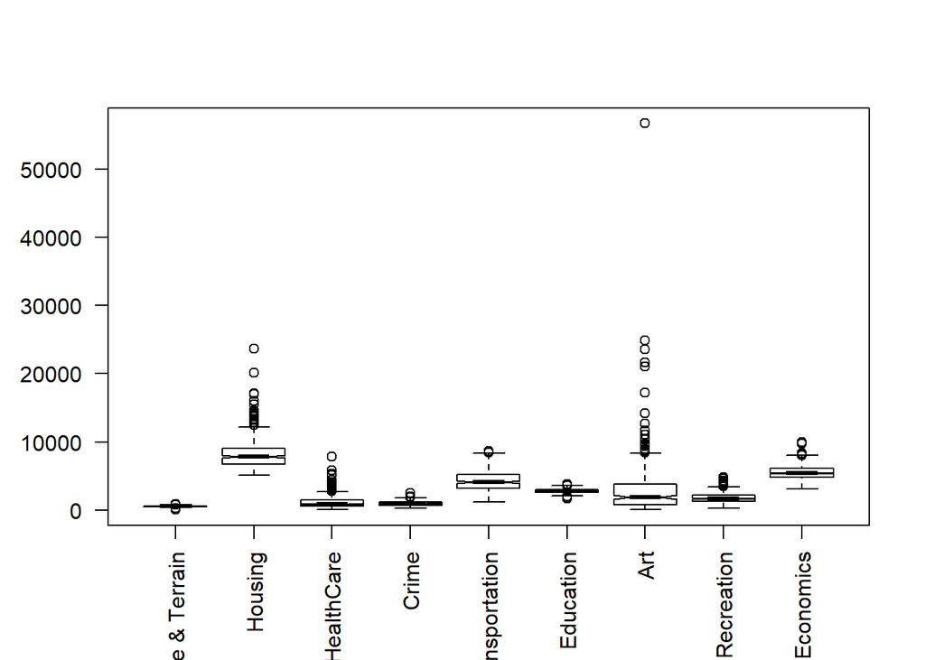

```r
boxplot(ratings,varwidth = T,notch = T ,outline = T, las = 2)
```

We can notice that there is more variability in the ratings of the arts and housing than in the ratings of crime and climate.

### 1.3.3 Methodology :

We need now to change the order of some parameters in order to have them all in this following shape : The higher the better the Housing and Crime need to be inverted so that the higher value will be the best.

```r
ratings$Housing <- -ratings$Housing
ratings$Crime <- -ratings$Crime
```

We will now scale our data as we did before to remove eventual variations.

```r
scale.ratings = scale(ratings)
head(scale.ratings)
```

```
##      Climate & Terrain     Housing HealthCare       Crime Transportation
## [1,]        -0.1467824  0.89992576 -0.9458990  0.10654981     -0.1234045
## [2,]         0.3002069  0.08743661  0.4688539  0.21014653      0.4637042
## [3,]        -0.5854941  0.42241020 -0.5660393 -0.02504601     -1.1570466
## [4,]        -0.5192735  0.18386205  0.2445273  0.98292201      1.8418937
## [5,]         0.9955236 -0.01946986  0.6652643 -1.46140045      1.6179379
## [6,]        -0.1550600  1.05965660 -0.5441052  0.65533240     -1.2169979
##       Education        Art Recreation  Economics
## [1,] -0.1804514 -0.4641863 -0.5458150  1.9434730
## [2,] -1.1748623  0.5198122  0.9729596 -1.0838164
## [3,] -0.7945547 -0.6276834 -1.2216511 -0.2539168
## [4,]  1.8208394  0.3240034 -0.2834024  0.3122592
## [5,]  0.6580957  0.2897530  0.9482037  0.1859300
## [6,]  0.4897628 -0.6067885 -1.0248417 -0.2502283
```

Now that our variables are set up correctly, we can move on to the PCA.

```r
fit <- prcomp(scale.ratings)
fit
```

```
## Standard deviations (1, .., p=9):
## [1] 1.8461560 1.1018059 1.0684003 0.9596446 0.8679199 0.7940793 0.7021736
## [8] 0.5639490 0.3469900
##
## Rotation (n x k) = (9 x 9):
##                          PC1        PC2          PC3         PC4        PC5
## Climate & Terrain  0.2064140  0.2178353 -0.689955982  0.13732125 -0.3691499
## Housing           -0.3565216 -0.2506240  0.208172230 -0.51182871 -0.2334878
## HealthCare         0.4602146 -0.2994653 -0.007324926  0.01470183 -0.1032405
## Crime             -0.2812984 -0.3553423 -0.185104981  0.53905047  0.5239397
## Transportation     0.3511508 -0.1796045  0.146376283 -0.30290371  0.4043485
## Education          0.2752926 -0.4833821  0.229702548  0.33541103 -0.2088191
## Art                0.4630545 -0.1947899 -0.026484298 -0.10108039 -0.1050976
## Recreation         0.3278879  0.3844746 -0.050852640 -0.18980082  0.5295406
## Economics          0.1354123  0.4712833  0.607314475  0.42176994 -0.1596201
##                           PC6         PC7         PC8           PC9
## Climate & Terrain  0.37460469 -0.08470577 -0.36230833  0.0013913515
## Housing            0.14163983  0.23063862 -0.61385513 -0.0136003402
## HealthCare        -0.37384804  0.01386761 -0.18567612 -0.7163548935
## Crime             -0.08092329 -0.01860646 -0.43002477  0.0586084614
## Transportation     0.46759180 -0.58339097 -0.09359866  0.0036294527
## Education          0.50216981  0.42618186  0.18866756  0.1108401911
## Art               -0.46188072 -0.02152515 -0.20398969  0.6857582127
## Recreation         0.08991578  0.62787789 -0.15059597 -0.0255062915
## Economics          0.03260813 -0.14974066 -0.40480926  0.0004377942
```

```r
s1 <- summary(fit)
R <- cor(ratings[,])
# Computing eigenvalues for our numeric matrice R :
r.eigen <- eigen(R)

fit
```

```
## Standard deviations (1, .., p=9):
## [1] 1.8461560 1.1018059 1.0684003 0.9596446 0.8679199 0.7940793 0.7021736
## [8] 0.5639490 0.3469900
##
## Rotation (n x k) = (9 x 9):
##                          PC1        PC2          PC3         PC4        PC5
## Climate & Terrain  0.2064140  0.2178353 -0.689955982  0.13732125 -0.3691499
## Housing           -0.3565216 -0.2506240  0.208172230 -0.51182871 -0.2334878
## HealthCare         0.4602146 -0.2994653 -0.007324926  0.01470183 -0.1032405
## Crime             -0.2812984 -0.3553423 -0.185104981  0.53905047  0.5239397
## Transportation     0.3511508 -0.1796045  0.146376283 -0.30290371  0.4043485
## Education          0.2752926 -0.4833821  0.229702548  0.33541103 -0.2088191
## Art                0.4630545 -0.1947899 -0.026484298 -0.10108039 -0.1050976
## Recreation         0.3278879  0.3844746 -0.050852640 -0.18980082  0.5295406
## Economics          0.1354123  0.4712833  0.607314475  0.42176994 -0.1596201
##                           PC6         PC7         PC8           PC9
## Climate & Terrain  0.37460469 -0.08470577 -0.36230833  0.0013913515
## Housing            0.14163983  0.23063862 -0.61385513 -0.0136003402
## HealthCare        -0.37384804  0.01386761 -0.18567612 -0.7163548935
## Crime             -0.08092329 -0.01860646 -0.43002477  0.0586084614
## Transportation     0.46759180 -0.58339097 -0.09359866  0.0036294527
## Education          0.50216981  0.42618186  0.18866756  0.1108401911
## Art               -0.46188072 -0.02152515 -0.20398969  0.6857582127
## Recreation         0.08991578  0.62787789 -0.15059597 -0.0255062915
## Economics          0.03260813 -0.14974066 -0.40480926  0.0004377942
```

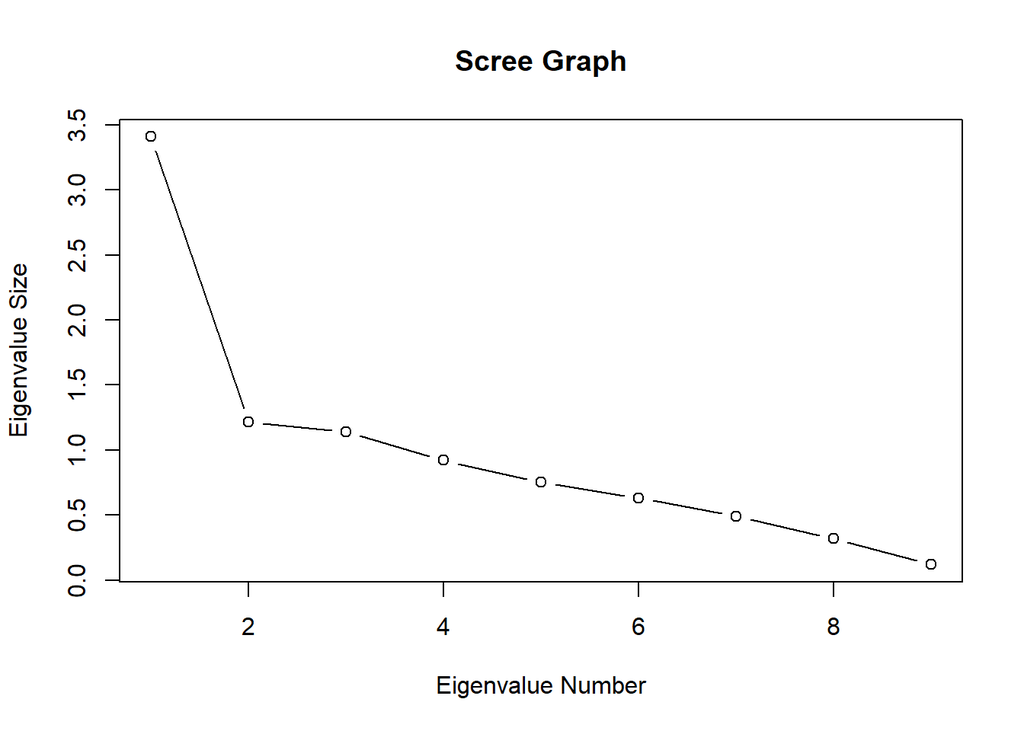

```r
plot(r.eigen$values, xlab = "Eigenvalue Number",
                     ylab = "Eigenvalue Size",
                     main = "Scree Graph",type = "b")
```

```r
pred.ratings = predict(fit)

cumsum(s1$importance[1,]^2) / sum(s1$importance[1,]^2)
```

```
##       PC1       PC2       PC3       PC4       PC5       PC6       PC7       PC8
## 0.3786991 0.5135853 0.6404163 0.7427405 0.8264389 0.8965013 0.9512844 0.9866220
##       PC9
## 1.0000000
```

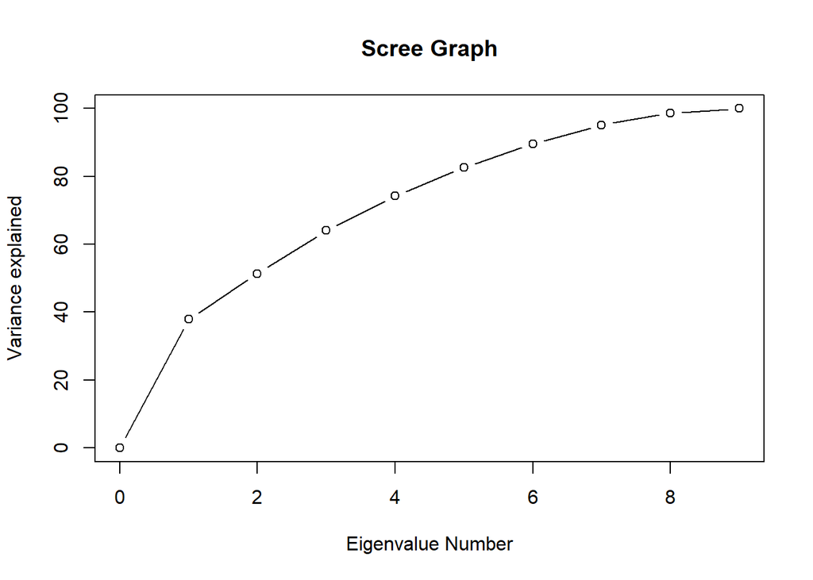

```r
vals <- cumsum(s1$importance[1,]^2) / sum(s1$importance[1,]^2)

plot(c(0, 1:length(vals)), c(0, 100* vals),
     ylim = c(0, 100),
     xlab = 'Eigenvalue Number',
     ylab = 'Variance explained',
     main = 'Scree Graph', type = "b")
```

We can clearly see from the graph, that the elbow is formed in PC2, and the cumulative proportion of the variance is 51%, which is not good. But, the second scree plot show that the only clear break in the amount of variance accounted for by each component is between the first and second components. However, the first component by itself explains less than 40% of the variance, so more components might be needed. We can see that the first three principal components explain roughly two-thirds of the toal variability in the standardized ratings, so that might be a reasonable way to reduce the dimensions.

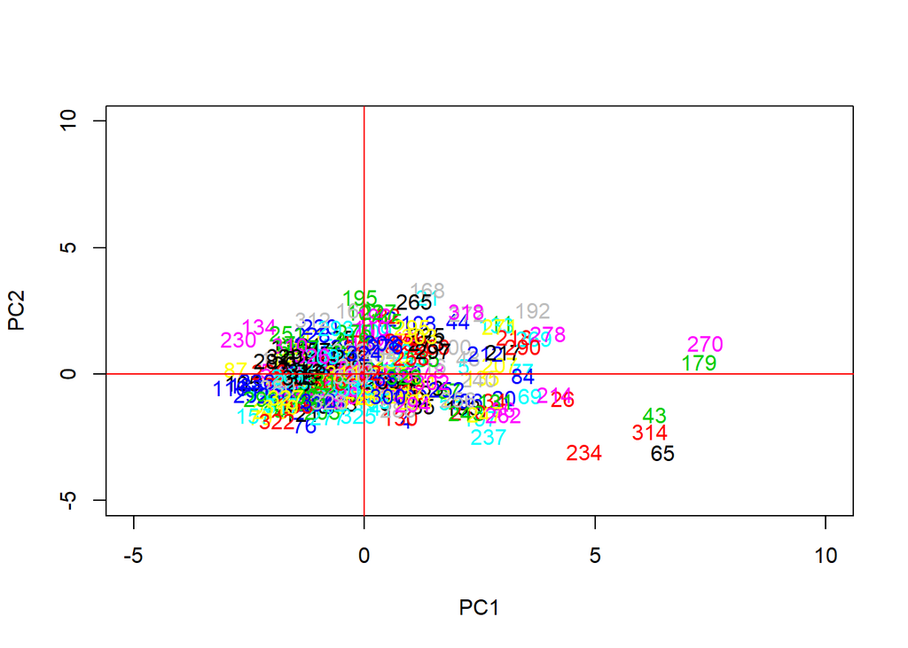

```r
{plot(pred.ratings[,1],pred.ratings[,2],type ="n",xlab ="PC1",ylab ="PC2",xlim = range(-5,10),ylim=range(-5,10))
  text(pred.ratings[,1],pred.ratings[,2],
       labels = ratings.complete$Index,col = ratings.complete$Index)
  abline(h=0,col = "red")
  abline(v=0,col ="red")}
```

We can see that there’s a huge concentration of points near the origin (0,0) coordinates because we have scaled the data. We also have some outliers, let’s take a look at them.

```r
points <- data.frame(pred.ratings[,1],pred.ratings[,2])
colnames(points)[1] <- "x"
colnames(points)[2] <- "y"

# Assigning a value(0,1,2) based on the number of negative signs in the coordinate. So that we can classify them easily
sign <- rep(0,length(points$x))
sign
```

[output not shown]

```r
  for(i in 1:length(points$x)){
    if(points$x[i] > 0 & points$y[i] > 0){
      sign[i] = 2
    }
    else if(points$x[i] < 0 & points$y[i] < 0){
      sign[i] = 0
    }
    else{
      sign[i] = 1
    }
  }

points$sign <- sign


# Calculating the distance from the origin (0,0) and the point.
distance.origin <- sqrt((points$x)^2 + (points$y)^2)
points$distance.origin <- distance.origin

# Getting the index from the ratings.complete.
points$index <- ratings.complete$Index
points <- points[order(points[,3],points[,4],decreasing = T),]
```

```r
points
points$rank <- seq(1,length(points$x))
```

[output not shown]

```r
ranking <- data.frame(points$rank,points$index)
ranking
```

[output not shown]

### 1.3.4 Conclusion :

We can conclude from our analysis that from the plot component graph we have some outliers points that appears to be more extreme than the remainder of the data. And from the Scree plot we can see that the first three principal components explain a big amount of our standardized dataset.